# R Bioconductor DNA Exploration

Prof. Harbert

# R Bioconductor

The [Bioconductor project](https://www.bioconductor.org/) provides tools for the analysis of genomic data in R. It is open-source and community driven with packages written, contributed, and maintained by bioinformatics scientists. There are more than [1900 packages included in the latest release](https://www.bioconductor.org/packages/release/BiocViews.html#___Software)

## Getting Started

To prepare for this lesson watch the video and review or follow along with the code linked below.

### Watch:

[video not shown]

### Code:

https://github.com/rsh249/bio331_2021/blob/main/R/r_dna1_vidcode.R

# Goal:

Today we want to explore *some* of the tools available for exploratory analysis of genomic data with Bioconductor. We will load a genome data file in the FASTA format (a raw DNA sequence data file like, but distinct from FASTQ). Our exploration will look across the *E. coli* genome for patterns in the sequence. Along the way we will practice using Bioconductor tools and base R code along with several visualizations in *ggplot2*.

*Think: Along the way make observations about the similarities and differences between FASTQ and FASTA file formats*

Try:

```bash
head SRR13764788.fastq
zcat genome.fna.gz | head
```

## Get Data and Read:

```r
#load libraries
library(ShortRead)
library(Biostrings)
library(ggplot2)

# get an E. coli genome from NCBI genomes FTP service
download.file('ftp://ftp.ncbi.nlm.nih.gov/genomes/refseq/bacteria/Escherichia_coli/reference/GCF_000005845.2_ASM584v2/GCF_000005845.2_ASM584v2_genomic.fna.gz',
              'genome.fna.gz')

# read genome.fna.gz
#COOL! Direct read of compressed data

genome = readDNAStringSet('genome.fna.gz')
```

## Basic DNA object exploration

```r
# genome length
nchar(genome)
```

```
## [1] 4641652
```

```r
# genome slicing
# [[1]] --> first sequence in the DNAStringSet (in this case there is only one)
# [1:10] --> get the first 10 nucleotides
genome[[1]][1:10]
```

```
## 10-letter DNAString object
## seq: AGCTTTTCAT
```

```r
genome[[1]][100000:100050]
```

```
## 51-letter DNAString object
## seq: TCCGGTTGTACTTCATGAACAAAACGGTATTGCGGGCTTAACCAATAAATG
```

## Counting Nucleotide Frequencies:

How many of each nucleotide are there in this sequence?

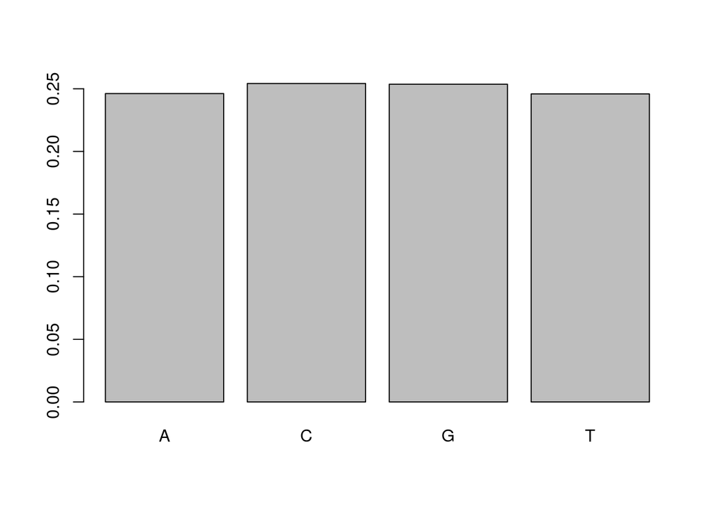

```r
geno.freq = alphabetFrequency(genome, as.prob=T)[,1:4] # frequency for A, C, G, or T
barplot(geno.freq) # Is this what we expect?
```

```r
#AT frequency
geno.freq[[1]] + geno.freq[[4]]
```

```
## [1] 0.4920929
```

```r
#GC frequency
geno.freq[[2]] + geno.freq[[3]]
```

```
## [1] 0.5079071
```

~50:50? [Expected for E. coli](http://dro.deakin.edu.au/eserv/DU:30034416/chen-bacterialgenomic-2010.pdf)

## How does nucleotide composition change over the genome

In [*Bioinformatics Algorithms Ch1*](https://youtu.be/M6qVRaNjcY0) there is a discussion about finding the origin of replication in bacteria by looking for the dnaA box sequences; “The Common Words Problem”. This chapter relies on algorithmic thinking to find common DNA sequence *words* known as kmers (aka oligomers). Kmer searching is a VERY common theme in bioinformatics. Organizing your searches on the basis of unique kmers can help your algorithm find target sequences in very large datasets.

For a simple example: If we wanted to do a naive search for possible coding sequence start sites we might look for all start codons “AUG” in a sequence. (Template: TAC; Complement: ATG). Let’s look at our genome squence for these words.

[BioStrings reference](https://bioconductor.org/packages/release/bioc/vignettes/BSgenome/inst/doc/GenomeSearching.pdf)

```r
p1 <- "ATG"
p2 <- "TAC"
count1 <- countPattern(p1, genome[[1]])
count2 <- countPattern(p2, genome[[1]])

count1 + count2
```

```
## [1] 128893
```

Hmm… How many genes are there in the *E. coli* genome? (Google It!)

*Think: What else might we need to know to better predict where genes are going to be in this sequence?* (Hint: Think like a biologist. What do you know about genes?)

Where are these matches found?

```r
match1 = matchPattern(p1, genome[[1]], max.mismatch = 0)
match2 = matchPattern(p2, genome[[1]], max.mismatch = 0)
match1
```

```
## Views on a 4641652-letter DNAString subject
## subject: AGCTTTTCATTCTGACTGCAACGGGCAATATGTC...CACCAAATAAAAAACGCCTTAGTAAGTATTTTTC
## views:
##             start     end width
##       [1]      30      32     3 [ATG]
##       [2]     190     192     3 [ATG]
##       [3]     337     339     3 [ATG]
##       [4]     374     376     3 [ATG]
##       [5]     416     418     3 [ATG]
##       ...     ...     ...   ... ...
##   [76278] 4641438 4641440     3 [ATG]
##   [76279] 4641485 4641487     3 [ATG]
##   [76280] 4641516 4641518     3 [ATG]
##   [76281] 4641581 4641583     3 [ATG]
##   [76282] 4641600 4641602     3 [ATG]
```

```r
match2
```

```
## Views on a 4641652-letter DNAString subject
## subject: AGCTTTTCATTCTGACTGCAACGGGCAATATGTC...CACCAAATAAAAAACGCCTTAGTAAGTATTTTTC
## views:
##             start     end width
##       [1]      83      85     3 [TAC]
##       [2]     129     131     3 [TAC]
##       [3]     171     173     3 [TAC]
##       [4]     178     180     3 [TAC]
##       [5]     213     215     3 [TAC]
##       ...     ...     ...   ... ...
##   [52607] 4641203 4641205     3 [TAC]
##   [52608] 4641331 4641333     3 [TAC]
##   [52609] 4641417 4641419     3 [TAC]
##   [52610] 4641471 4641473     3 [TAC]
##   [52611] 4641540 4641542     3 [TAC]
```

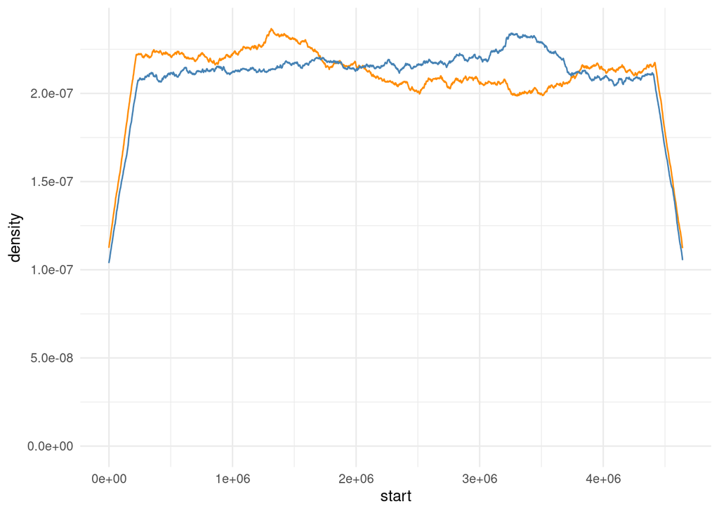

```r
matchdf1 = as.data.frame(match1@ranges)
matchdf2 = as.data.frame(match2@ranges)

ggplot() +
  geom_density(data=matchdf1, aes(x=start), kernel='rectangular', n=4600, col='darkorange') +
  geom_density(data=matchdf2, aes(x=start), kernel='rectangular', n=4600, col='steelblue') +
  theme_minimal()
```

*Think: What is this graph showing you? … Maybe nothing, but maybe something*

## GC Ratio and DNA replication

Here we are going to implement a modified solution to the GC ratio map to help find the pattern of deamination mutations associated with lagging strand DNA replication. [Watch Ch1 part 3](https://youtu.be/xmaag0IJO0c)

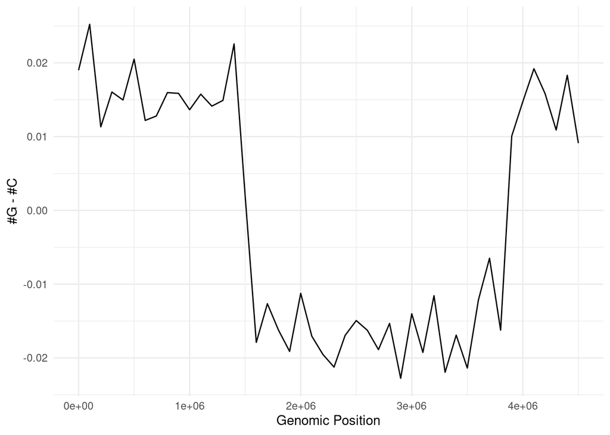

```r
# calculate G and C counts in 100kb windows
slidingGC = letterFrequencyInSlidingView(genome[[1]],
                                         view.width=100000,
                                         letters=c("C", "G"),
                                         as.prob = T)
#convert to data frame
slidingGC = as.data.frame(slidingGC)
#compute G - C values for each window
slidingGC$ratio = slidingGC$G - slidingGC$C
#calculate genome positions (row numbers)
slidingGC$position = 1:nrow(slidingGC)

#sample to 100,000 nucleotide bins (to make plotting better)
sampleGC = slidingGC[seq(1, nrow(slidingGC), by=100000),]

ggplot(sampleGC) +
  geom_path(aes(x = position, y = ratio)) +
  theme_minimal() +
  xlab("Genomic Position") +
  ylab("#G - #C")
```

# Homework:

1. Read FASTQ data and plot read lengths and quality scores. [Watch demo here](https://youtu.be/E_HfxDJRE10). Get fastq data using SRA ID number: SRR11206996
2. Download the genome for Cholera (*Vibrio cholerae*) Use: *“ftp://ftp.ncbi.nlm.nih.gov/genomes/refseq/bacteria/Vibrio_cholerae/representative/GCF_000829215.1_ASM82921v1/GCF_000829215.1_ASM82921v1_genomic.fna.gz”* to download the FASTA sequence file. Plot the frequency of all four nucleotides across the genome. Is it the same as *E. coli*? Create a plot of start codon kmers (ATG and TAC) density along the genome. How does this compare to *E. coli*? Create a visualization of the G - C difference in 100kb windows across the genome. Do we see evidence for a similar pattern around a hypothetical *ori* region?

Submission details and dropbox link on eLearn course website.

[Home](https://bio331.devbioinformatics.org)